# Text and Sentiment Analysis in R

# Tokenising

The first step to analysing text in R is to convert it into a form that will make it easier to process. This includes tidying the text, and arranging it into a tidy tibble.

Let’s start by importing the `tidyverse` and also the [tidytext](https://cran.r-project.org/web/packages/tidytext/vignettes/tidytext.html) library.

```r
library(tidyverse)
library(tidytext)
```

Next, we need to create some text that we will analyse. Let’s start with the first few lines of Hamlet’s famous soliloquy. We will create this as a vector, with each element in the vector being one line of the speech.

```r
text = c("To be, or not to be--that is the question:",
         "Whether 'tis nobler in the mind to suffer",
         "The slings and arrows of outrageous fortune",
         "Or to take arms against a sea of troubles",
         "And by opposing end them.")
```

Our next step is to convert this vector into a tibble. We want the tibble to have two columns:

1. `line` will hold the line number. There are five lines, so this will be the count from `1:5`.
2. `text` will hold each line of text.

```r
text <- tibble(line=1:5, text=text)
text
```

| line | text |
| --- | --- |
| 1 | To be, or not to be--that is the question: |
| 2 | Whether 'tis nobler in the mind to suffer |
| 3 | The slings and arrows of outrageous fortune |
| 4 | Or to take arms against a sea of troubles |
| 5 | And by opposing end them. |

| line <int> | text <chr> |  |  |  |
| --- | --- | --- | --- | --- |
| 1 | To be, or not to be--that is the question: |  |  |  |
| 2 | Whether 'tis nobler in the mind to suffer |  |  |  |
| 3 | The slings and arrows of outrageous fortune |  |  |  |
| 4 | Or to take arms against a sea of troubles |  |  |  |
| 5 | And by opposing end them. |  |  |  |

5 rows

We now want to rearrange this tibble into a tidy text format. Remember, tidy data is data where;

1. every variable has its own column,
2. every observation has its own row,
3. each value must have its own cell.

So what is the “observation” when analysing text? In tidy text, an observation is called a “token”. A token is the smallest unit of text that you want to analyse. For example, a token could be;

1. individual letters
2. individual words
3. combination of neighbouring words (n-grams)
4. individual lines
5. individual paragraphs

etc. The token is the smallest unit of text that you need to use for your analysis, i.e. the atomic unit. It is up to you to decide what the appropriate token type is for your analysis. For example, if we were counting the number of times each word appeared in the text, then the token would be a word. If we were analysing average line lengths, then the token would be a line.

Let’s count the number of times each word appears. For this analysis, the token (and thus observation) is a word. Each observation must have its own row, meaning that we need to transform the tibble so that there is one word per row. But what about the first rule that every variable has its own column? What are the variables for this text?

There are two variables:

1. The line number, which is in the column `line`
2. The actual token (word), which we will put in a column called `word`.

We therefore need to transform our tibble so that we have two columns; `line` and `word`. And each word should be on a separate row.

We could do this manually. Fortunately the `tidytext` library supplies the function [unnest_tokens](https://rdrr.io/cran/tidytext/man/unnest_tokens.html), which can automatically do this for us.

```r
tokens <- text %>% unnest_tokens(word, text)
tokens
```

| line | word |
| --- | --- |
| 1 | to |
| 1 | be |
| 1 | or |
| 1 | not |
| 1 | to |
| 1 | be |
| 1 | that |
| 1 | is |
| 1 | the |
| 1 | question |

[output cut: 29 more lines]

| line <int> | word <chr> |  |  |  |
| --- | --- | --- | --- | --- |
| 4 | a |  |  |  |
| 4 | sea |  |  |  |
| 4 | of |  |  |  |
| 4 | troubles |  |  |  |
| 5 | and |  |  |  |
| 5 | by |  |  |  |
| 5 | opposing |  |  |  |
| 5 | end |  |  |  |
| 5 | them |  |  |  |

Next

1234

Previous

31-39 of 39 rows

By default `unnest_tokens` will tokenise by words. You can change this by passing different options to the function (e.g. as we will do later when we will tokenise by n-grams). The first argument is the name of the column in which to place the tokens, while the second argument is the name of the column that contains the text to tokenise.

Note that `unnest_tokens` has automatically lower-cased the words and removed punctuation.

Now that the text is tidy, it is easy to count the number of occurrences of each word. We can do this using the [count](https://dplyr.tidyverse.org/reference/count.html) function from the tidyverse’s [dplyr](https://dplyr.tidyverse.org/index.html) package. We will pass `sort=TRUE` so that the resulting tibble is sorted with the most common words at the top.

```r
tokens %>% count(word, sort=TRUE)
```

| word | n |
| --- | --- |
| to | 4 |
| the | 3 |
| and | 2 |
| be | 2 |
| of | 2 |
| or | 2 |
| a | 1 |
| against | 1 |
| arms | 1 |
| arrows | 1 |

[output cut: 20 more lines]

| word <chr> | n <int> |  |  |  |
| --- | --- | --- | --- | --- |
| to | 4 |  |  |  |
| the | 3 |  |  |  |
| and | 2 |  |  |  |
| be | 2 |  |  |  |
| of | 2 |  |  |  |
| or | 2 |  |  |  |
| a | 1 |  |  |  |
| against | 1 |  |  |  |
| arms | 1 |  |  |  |
| arrows | 1 |  |  |  |

Next

123

Previous

1-10 of 30 rows

## Reading text from a file

Tidying the text makes all subsequent analysis significantly easier. But, of course, before we can tidy the text, we have to load it into R. Typing it out into a vector, as we did above, would not be practical for large amounts of text!

Fortunately R comes with many functions to read text from files. The readLines function from core R reads text from a file into a vector of lines. For example, I’ve put the whole of Hamlet’s soliloquy online at https://chryswoods.com/text_analysis_r/hamlet.txt. We can load this via;

```r
lines <- readLines("https://chryswoods.com/text_analysis_r/hamlet.txt")
lines
```

```
##  [1] "HAMLET"
##  [2] "A monologue from the play by William Shakespeare"
##  [3] ""
##  [4] "To be, or not to be--that is the question:"
##  [5] "Whether 'tis nobler in the mind to suffer"
##  [6] "The slings and arrows of outrageous fortune"
##  [7] "Or to take arms against a sea of troubles"
##  [8] "And by opposing end them. To die, to sleep--"
##  [9] "No more--and by a sleep to say we end"
## [10] "The heartache, and the thousand natural shocks"
## [11] "That flesh is heir to. 'Tis a consummation"
## [12] "Devoutly to be wished. To die, to sleep--"
## [13] "To sleep--perchance to dream: ay, there's the rub,"
## [14] "For in that sleep of death what dreams may come"
## [15] "When we have shuffled off this mortal coil,"
```

[output cut: 23 more lines]

We will now convert this into a tibble. One column, called `line`, will have the line number (from 1 to `length(lines)`), while the lines themselves will be placed into the column called `text`.

```r
hamlet <- tibble(line=1:length(lines), text=lines)
hamlet
```

| line | text |
| --- | --- |
| 1 | HAMLET |
| 2 | A monologue from the play by William Shakespeare |
| 3 |  |
| 4 | To be, or not to be--that is the question: |
| 5 | Whether 'tis nobler in the mind to suffer |
| 6 | The slings and arrows of outrageous fortune |
| 7 | Or to take arms against a sea of troubles |
| 8 | And by opposing end them. To die, to sleep-- |
| 9 | No more--and by a sleep to say we end |
| 10 | The heartache, and the thousand natural shocks |

[output cut: 28 more lines]

| line <int> | text <chr> |  |  |  |
| --- | --- | --- | --- | --- |
| 1 | HAMLET |  |  |  |
| 2 | A monologue from the play by William Shakespeare |  |  |  |
| 3 |  |  |  |  |
| 4 | To be, or not to be--that is the question: |  |  |  |
| 5 | Whether 'tis nobler in the mind to suffer |  |  |  |
| 6 | The slings and arrows of outrageous fortune |  |  |  |
| 7 | Or to take arms against a sea of troubles |  |  |  |
| 8 | And by opposing end them. To die, to sleep-- |  |  |  |
| 9 | No more--and by a sleep to say we end |  |  |  |
| 10 | The heartache, and the thousand natural shocks |  |  |  |

Next

1234

Previous

1-10 of 38 rows

We can now tokenise the text using `unnest_tokens` again, and then count the numbers;

```r
hamlet_tokens <- hamlet %>% unnest_tokens(word, text)
hamlet_tokens %>% count(word, sort=TRUE)
```

| word | n |
| --- | --- |
| the | 21 |
| of | 15 |
| to | 15 |
| and | 12 |
| that | 7 |
| a | 6 |
| sleep | 5 |
| be | 4 |
| we | 4 |
| bear | 3 |

[output cut: 162 more lines]

| word <chr> | n <int> |  |  |  |
| --- | --- | --- | --- | --- |
| the | 21 |  |  |  |
| of | 15 |  |  |  |
| to | 15 |  |  |  |
| and | 12 |  |  |  |
| that | 7 |  |  |  |
| a | 6 |  |  |  |
| sleep | 5 |  |  |  |
| be | 4 |  |  |  |
| we | 4 |  |  |  |
| bear | 3 |  |  |  |

Next

123456

...

18

Previous

1-10 of 172 rows

Analysis is made difficult because the text contains lots of short words, like “the”, “of” and “and”, which form the scaffolding of the sentences without necessarily containing meaning in and of themselves. These words, which are often called “stop words”, are sometimes not needed for textual analysis, and should be removed. Fortunately the tidytext library provides a data set of English stop words;

```r
data(stop_words)
stop_words
```

| word | lexicon |
| --- | --- |
| a | SMART |
| a's | SMART |
| able | SMART |
| about | SMART |
| above | SMART |
| according | SMART |
| accordingly | SMART |
| across | SMART |
| actually | SMART |
| after | SMART |

[output cut: 1139 more lines]

| word <chr> | lexicon <chr> |  |  |  |
| --- | --- | --- | --- | --- |
| a | SMART |  |  |  |
| a's | SMART |  |  |  |
| able | SMART |  |  |  |
| about | SMART |  |  |  |
| above | SMART |  |  |  |
| according | SMART |  |  |  |
| accordingly | SMART |  |  |  |
| across | SMART |  |  |  |
| actually | SMART |  |  |  |
| after | SMART |  |  |  |

Next

123456

...

115

Previous

1-10 of 1,149 rows

We can remove these stop words from `hamlet_tokens` by performing an anti-join between `hamlet_tokens` and `stop_words`. An anti-join combines two tibbles, returning only the rows in the first tibble that are NOT in the second tibble. We use the [anti-join](https://dplyr.tidyverse.org/reference/filter-joins.html) function that is part of [dplyr](https://dplyr.tidyverse.org/index.html).

```r
important_hamlet_tokens <- hamlet_tokens %>% anti_join(stop_words)
important_hamlet_tokens
```

| line | word |
| --- | --- |
| 1 | hamlet |
| 2 | monologue |
| 2 | play |
| 2 | william |
| 2 | shakespeare |
| 4 | question |
| 5 | tis |
| 5 | nobler |
| 5 | mind |
| 5 | suffer |

[output cut: 106 more lines]

| line <int> | word <chr> |  |  |  |
| --- | --- | --- | --- | --- |
| 1 | hamlet |  |  |  |
| 2 | monologue |  |  |  |
| 2 | play |  |  |  |
| 2 | william |  |  |  |
| 2 | shakespeare |  |  |  |
| 4 | question |  |  |  |
| 5 | tis |  |  |  |
| 5 | nobler |  |  |  |
| 5 | mind |  |  |  |
| 5 | suffer |  |  |  |

Next

123456

...

12

Previous

1-10 of 116 rows

Now, when we count the words, we will only get the meaningful words;

```r
important_hamlet_tokens %>% count(word, sort=TRUE)
```

| word | n |
| --- | --- |
| sleep | 5 |
| bear | 3 |
| death | 2 |
| die | 2 |
| life | 2 |
| makes | 2 |
| tis | 2 |
| action | 1 |
| arms | 1 |
| arrows | 1 |

[output cut: 95 more lines]

| word <chr> | n <int> |  |  |  |
| --- | --- | --- | --- | --- |
| sleep | 5 |  |  |  |
| bear | 3 |  |  |  |
| death | 2 |  |  |  |
| die | 2 |  |  |  |
| life | 2 |  |  |  |
| makes | 2 |  |  |  |
| tis | 2 |  |  |  |
| action | 1 |  |  |  |
| arms | 1 |  |  |  |
| arrows | 1 |  |  |  |

Next

123456

...

11

Previous

1-10 of 105 rows

The top words, “sleep”, “death”, “die”, “life”, are a good insight into the meaning behind this speech.

We can combine all of the above steps into a single pipeline;

```r
hamlet %>% unnest_tokens(word, text) %>%
  anti_join(stop_words) %>%
  count(word, sort=TRUE)
```

| word | n |
| --- | --- |
| sleep | 5 |
| bear | 3 |
| death | 2 |
| die | 2 |
| life | 2 |
| makes | 2 |
| tis | 2 |
| action | 1 |
| arms | 1 |
| arrows | 1 |

[output cut: 95 more lines]

| word <chr> | n <int> |  |  |  |
| --- | --- | --- | --- | --- |
| sleep | 5 |  |  |  |
| bear | 3 |  |  |  |
| death | 2 |  |  |  |
| die | 2 |  |  |  |
| life | 2 |  |  |  |
| makes | 2 |  |  |  |
| tis | 2 |  |  |  |
| action | 1 |  |  |  |
| arms | 1 |  |  |  |
| arrows | 1 |  |  |  |

Next

123456

...

11

Previous

1-10 of 105 rows

## Downloading texts

To do more text analysis we need to find some larger texts. Fortunately, the [gutenbergr](https://docs.ropensci.org/gutenbergr/) package makes it easy to download books from [Project Gutenberg](https://www.gutenberg.org/).

```r
library(gutenbergr)
```

Lets start by downloading “The Adventures of Sherlock Holmes”. The Gutenberg ID of this book is 1661 (found via the [search engine](https://www.gutenberg.org/ebooks/)).

```r
sherlock <- gutenberg_download(1661)
sherlock
```

| gutenberg_id | text |
| --- | --- |
| 1661 | THE ADVENTURES OF SHERLOCK HOLMES |
| 1661 |  |
| 1661 | by |
| 1661 |  |
| 1661 | SIR ARTHUR CONAN DOYLE |
| 1661 |  |
| 1661 |  |
| 1661 |  |
| 1661 | I. A Scandal in Bohemia |
| 1661 | II. The Red-headed League |

[output cut: 9990 more lines]

| gutenberg_id <int> | text <chr> |  |  |
| --- | --- | --- | --- |
| 1661 | THE ADVENTURES OF SHERLOCK HOLMES |  |  |
| 1661 |  |  |  |
| 1661 | by |  |  |
| 1661 |  |  |  |
| 1661 | SIR ARTHUR CONAN DOYLE |  |  |
| 1661 |  |  |  |
| 1661 |  |  |  |
| 1661 |  |  |  |
| 1661 | I. A Scandal in Bohemia |  |  |
| 1661 | II. The Red-headed League |  |  |

Next

123456

...

1000

Previous

1-10 of 10,000 rows

We can now perform the same analysis as above, namely tokenising by word, removing stop words, and then counting words to find the most common;

```r
sherlock %>%
  unnest_tokens(word, text) %>%
  anti_join(stop_words) %>%
  count(word, sort=TRUE)
```

| word | n |
| --- | --- |
| holmes | 462 |
| time | 151 |
| door | 144 |
| matter | 125 |
| house | 123 |
| hand | 120 |
| night | 114 |
| heard | 113 |
| found | 108 |
| day | 106 |

[output cut: 7430 more lines]

| word <chr> | n <int> |  |  |  |
| --- | --- | --- | --- | --- |
| holmes | 462 |  |  |  |
| time | 151 |  |  |  |
| door | 144 |  |  |  |
| matter | 125 |  |  |  |
| house | 123 |  |  |  |
| hand | 120 |  |  |  |
| night | 114 |  |  |  |
| heard | 113 |  |  |  |
| found | 108 |  |  |  |
| day | 106 |  |  |  |

Next

123456

...

744

Previous

1-10 of 7,440 rows

This has shown all words, including words that only appeared once. We can narrow this down by using the [filter](https://dplyr.tidyverse.org/reference/filter.html) function from [dplyr](https://dplyr.tidyverse.org/index.html) to filter in only words that appear more than 75 times;

```r
counts <- sherlock %>%
            unnest_tokens(word, text) %>%
            anti_join(stop_words) %>%
            count(word, sort=TRUE) %>%
            filter(n > 75)
counts
```

| word | n |
| --- | --- |
| holmes | 462 |
| time | 151 |
| door | 144 |
| matter | 125 |
| house | 123 |
| hand | 120 |
| night | 114 |
| heard | 113 |
| found | 108 |
| day | 106 |

[output cut: 11 more lines]

| word <chr> | n <int> |  |  |  |
| --- | --- | --- | --- | --- |
| holmes | 462 |  |  |  |
| time | 151 |  |  |  |
| door | 144 |  |  |  |
| matter | 125 |  |  |  |
| house | 123 |  |  |  |
| hand | 120 |  |  |  |
| night | 114 |  |  |  |
| heard | 113 |  |  |  |
| found | 108 |  |  |  |
| day | 106 |  |  |  |

Next

123

Previous

1-10 of 21 rows

To plot this data, we need to convert the words from being stored as text, to be represented as [factors](https://www.w3schools.com/r/r_factors.asp). We do this using the core R [reorder](https://www.rdocumentation.org/packages/stats/versions/3.6.2/topics/reorder.default) function. This will order the factors according to the number of occurances of each word. As we are changing the tibble, we need to use the dplyr [mutate](https://dplyr.tidyverse.org/reference/mutate.html) to edit the column in place;

```r
counts <- counts %>% mutate(word = reorder(word, n))
```

The data is now ready to be rendered as a bar graph. We can do this using [ggplot](https://ggplot2.tidyverse.org/), using the aesthetic of placing the number of occurances on the x axis, the word on the y axis, using a `geom_col()` column plot, and not adding a label on the y-axis;

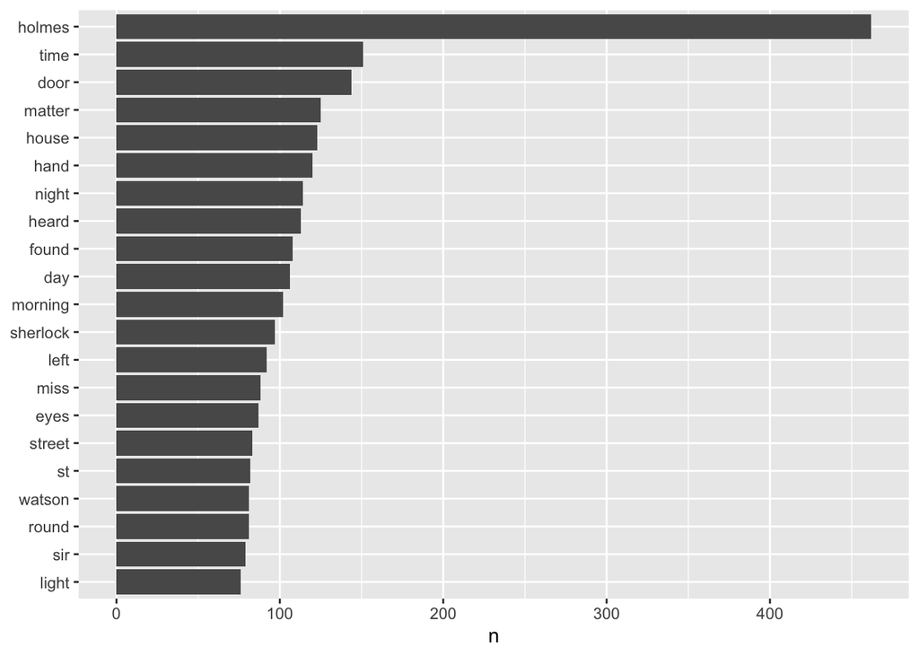

```r
counts %>% ggplot(aes(n, word)) + geom_col() + labs(y=NULL)
```

## EXERCISE

Go onto [Project Gutenberg](https://www.gutenberg.org/) and find a book that you want to analyse. Download the book and create a graph of the most common words (ignoring stop words).

[Example answer](https://chryswoods.com/text_analysis_r/tokenising_answer.html)

## [Previous](https://chryswoods.com/text_analysis_r/index.html) | [Next](https://chryswoods.com/text_analysis_r/sentiment.html)